# Regresión Lineal Multivariada

Predicción de calidad del café · Semana 14

Juan Sebastián Guayazán · Esteban Valente · Diego Nocua

20 de noviembre de 2026

> **Semana 14 del programa:** Regresión lineal simple y múltiple, selección de variables, diagnósticos de regresión, predicción y comparación con modelos AA/ML.

> **Advertencia metodológica importante:** `Total.Cup.Points` es el puntaje total construido a partir de los atributos sensoriales, y el modelo usa esos atributos como predictores. Esto introduce una relación aritmética directa entre entradas y respuesta. El ejercicio estudia esa asociación/reconstrucción, pero un buen ajuste no demuestra que el modelo pueda predecir calidad antes de la catación ni que generalice a una medición independiente.

**En resumen.** El puntaje total de catación es **la suma de los diez atributos sensoriales**, así que cualquier modelo que los use como predictores tiene R² ≈ 1: reconstruye la suma, no predice calidad. Incluso un solo atributo (el sabor) explica el 71 % de la variación. El modelo que sí responde una pregunta real usa solo origen, altitud, humedad, defectos y proceso: su R² predictivo en prueba es 0,13, es decir, explica poco del puntaje.

# Qué responde este informe

**Preguntas:** (1) ¿cuánto del puntaje total de catación se explica con los atributos sensoriales y la altitud? (2) ¿qué se puede estimar del puntaje usando solo variables que **no** forman parte de la suma (origen, altitud, humedad, defectos y proceso)?

Cada sección sigue el mismo esquema: *qué se hace y por qué*, *el resultado* y *cómo se lee*.

| Sección | Qué se hace | Mensaje principal |
| --- | --- | --- |
| 1 | Datos y respuesta | El puntaje total es la suma de los diez atributos |
| 2 | Regresión simple | Un solo atributo ya explica mucho |
| 3–4 | Regresión múltiple y diagnósticos | R² ≈ 1 por construcción; los diagnósticos no son sustantivos |
| 5 | Selección de variables | Stepwise y mejor subconjunto |
| 6 | Predicción | El ajuste es casi perfecto por la identidad contable |
| 7 | Modelo sin circularidad | La cifra que conviene presentar |

# 1. Datos y variable respuesta

Se modela el **puntaje total de taza** (`Total.Cup.Points`) a partir de los 10 atributos sensoriales y la altitud. Dado que el puntaje total se construye con los atributos sensoriales, el análisis es principalmente explicativo/descriptivo de esa relación y no una predicción independiente.

```r
library(dplyr)
library(ggplot2)
library(car)
library(broom)     # tidy(), glance(), augment()
library(MASS)      # stepAIC()
library(leaps)     # regsubsets()

data_raw <- read.csv("../data/arabica_data_cleaned.csv")

vars_originales <- c("Aroma","Flavor","Aftertaste","Acidity","Body","Balance",
                     "Uniformity","Clean.Cup","Sweetness","Cupper.Points",
                     "Moisture","Category.One.Defects","Category.Two.Defects",
                     "altitude_mean_meters","Total.Cup.Points")

datos <- data_raw %>%
  filter(!is.na(altitude_mean_meters),
         altitude_mean_meters > 0, altitude_mean_meters <= 3000) %>%
  dplyr::select(all_of(vars_originales), Processing.Method, Country.of.Origin) %>%
  filter(complete.cases(.[, vars_originales])) %>%
  rename(Sabor=Flavor, Retrogusto=Aftertaste, Acidez=Acidity, Cuerpo=Body,
         Uniformidad=Uniformity, Taza.Limpia=Clean.Cup, Dulzura=Sweetness,
         Puntaje.Catador=Cupper.Points, Humedad=Moisture,
         Defectos.Cat1=Category.One.Defects, Defectos.Cat2=Category.Two.Defects,
         Altitud=altitude_mean_meters, Puntaje.Total=Total.Cup.Points)

vars_pred <- c("Aroma","Sabor","Retrogusto","Acidez","Cuerpo","Balance",
               "Uniformidad","Taza.Limpia","Dulzura","Puntaje.Catador","Altitud")

cat("Dimensiones:", nrow(datos), "×", ncol(datos), "\n")
```

```
## Dimensiones: 1070 × 17
```

```r
cat("Variable respuesta: Puntaje.Total\n")
```

```
## Variable respuesta: Puntaje.Total
```

```r
summary(datos$Puntaje.Total)
```

```
##    Min. 1st Qu.  Median    Mean 3rd Qu.    Max.
##    0.00   81.25   82.50   82.14   83.67   90.58
```

```r
# Un lote tiene todos los atributos y el puntaje total en 0: es un registro vacío,
# no una catación real. Con residuo de −21,5 puntos domina la regresión simple
# (su intercepto) y los diagnósticos, así que se excluye.
n_cero <- sum(datos$Puntaje.Total == 0)
cat("Lotes con Puntaje.Total = 0:", n_cero, "\n")
```

```
## Lotes con Puntaje.Total = 0: 1
```

```r
datos <- datos %>% filter(Puntaje.Total > 0)
cat("Lotes analizados:", nrow(datos), "\n")
```

```
## Lotes analizados: 1069
```

**Cómo se lee.** Se parte de los lotes con altitud válida y registros completos. Hay 1 lote(s) con puntaje total 0, un registro vacío (todos los atributos en 0) que se excluye porque domina la regresión; quedan **1.069 lotes**.

## 1.1. El puntaje total es la suma de los diez atributos

```r
diferencia <- datos$Puntaje.Total - rowSums(datos[, setdiff(vars_pred, "Altitud")])
cat("Puntaje.Total − suma de los 10 atributos:\n"); print(summary(round(diferencia, 3)))
```

```
## Puntaje.Total − suma de los 10 atributos:
```

```
##       Min.    1st Qu.     Median       Mean    3rd Qu.       Max.
## -0.5000000  0.0000000  0.0000000  0.0002245  0.0100000  0.1000000
```

```r
cat("Lotes con diferencia exactamente 0:", sum(abs(diferencia) < 1e-9), "de", nrow(datos), "\n")
```

```
## Lotes con diferencia exactamente 0: 521 de 1069
```

**Cómo se lee.** La diferencia entre el puntaje total y la suma de los diez atributos es **exactamente cero** en 521 de 1.069 lotes, y en el resto no pasa de 0,50 puntos (diferencias de redondeo del registro). Es decir, el puntaje total no es una medida independiente: es la suma.

Por construcción, el modelo múltiple de las secciones 3 a 6 recupera esta identidad contable: los coeficientes de los diez atributos son ≈ 1, la altitud ≈ 0 y R² ≈ 1. Los residuos son errores de redondeo del registro, así que los diagnósticos (normalidad, homocedasticidad) y los valores p no tienen interpretación sustantiva. La sección 7 plantea un modelo que sí predice algo que no está en sus entradas.

# 2. Regresión lineal simple

Exploración del predictor más correlacionado con el puntaje total.

```r
cors <- cor(datos[, vars_pred], datos$Puntaje.Total)
mejor_var <- rownames(cors)[which.max(abs(cors[,1]))]
cat("Variable más correlacionada:", mejor_var,
    "  r =", round(cors[mejor_var,], 4), "\n")
```

```
## Variable más correlacionada: Sabor   r = 0.8434
```

```r
modelo_simple <- lm(reformulate(mejor_var, response = "Puntaje.Total"), data=datos)
summary(modelo_simple)
```

```
##
## Call:
## lm(formula = reformulate(mejor_var, response = "Puntaje.Total"),
##     data = datos)
##
## Residuals:
##      Min       1Q   Median       3Q      Max
## -16.6537  -0.3987   0.1590   0.6666   3.5163
##
## Coefficients:
##             Estimate Std. Error t value Pr(>|t|)
## (Intercept)  31.7751     0.9847   32.27   <2e-16 ***
## Sabor         6.7029     0.1307   51.27   <2e-16 ***
## ---
## Signif. codes:  0 '***' 0.001 '**' 0.01 '*' 0.05 '.' 0.1 ' ' 1
##
## Residual standard error: 1.424 on 1067 degrees of freedom
## Multiple R-squared:  0.7113, Adjusted R-squared:  0.711
## F-statistic:  2629 on 1 and 1067 DF,  p-value: < 2.2e-16
```

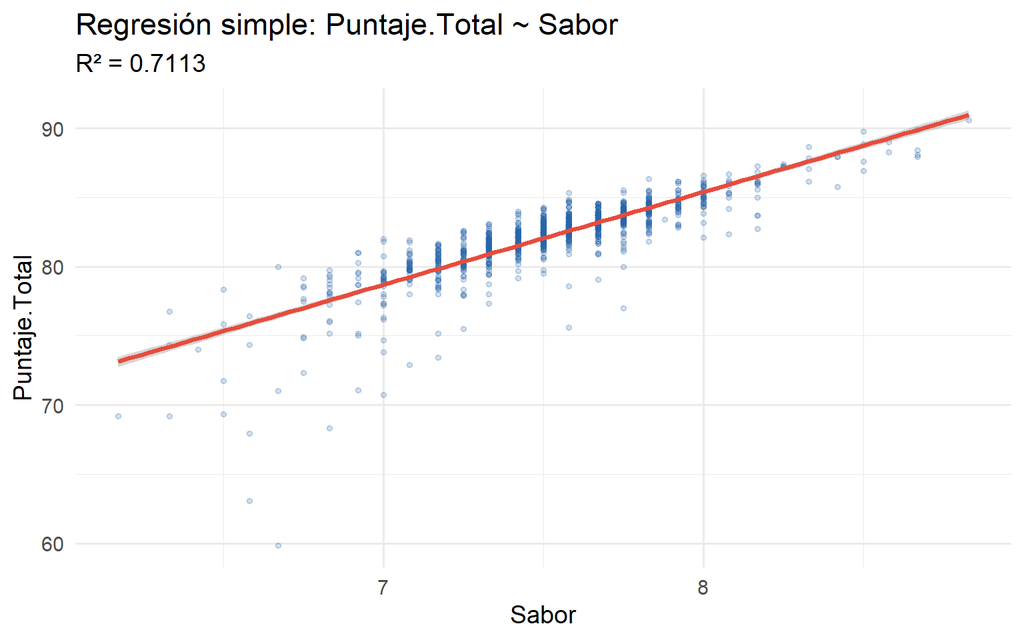

```r
ggplot(datos, aes(x=.data[[mejor_var]], y=.data$Puntaje.Total)) +
  geom_point(alpha=0.2, color="#2563a8", size=1.2) +
  geom_smooth(method="lm", color="#e74c3c", se=TRUE) +
  labs(title=paste0("Regresión simple: Puntaje.Total ~ ", mejor_var),
       subtitle=paste0("R² = ", round(summary(modelo_simple)$r.squared, 4))) +
  theme_minimal(base_size = 14)
```

**Qué hacemos y por qué.** La regresión lineal simple ajusta una recta entre una variable explicativa y la respuesta. Se elige el predictor más correlacionado con el puntaje total: **Sabor** (r = 0,843).

# 3. Regresión lineal múltiple (modelo completo)

```r
formula_completa <- as.formula(paste("Puntaje.Total ~", paste(vars_pred, collapse=" + ")))
modelo_completo  <- lm(formula_completa, data=datos)

glance(modelo_completo)
```

| r.squared | adj.r.squared | sigma | statistic | p.value | df | logLik | AIC | BIC | deviance | df.residual | nobs |
| --- | --- | --- | --- | --- | --- | --- | --- | --- | --- | --- | --- |
| 0.9999569 | 0.9999565 | 0.01746824 | 2231279 | 0 | 11 | 2815.828 | -5605.657 | -5540.989 | 0.3225322 | 1057 | 1069 |

**Qué hacemos y por qué.** La regresión múltiple usa todos los predictores a la vez: `Puntaje.Total = b0 + b1·Aroma + ... + b11·Altitud`.

**Cómo se lee.** El R² es 1,0000 y el error típico residual 0,017 puntos: el ajuste es casi perfecto **porque el puntaje total es la suma de los atributos**, no porque el modelo “prediga” calidad.

```r
tidy(modelo_completo, conf.int=TRUE) %>%
  filter(term != "(Intercept)") %>%
  arrange(desc(abs(estimate))) %>%
  mutate(across(where(is.numeric), ~ round(., 4)))
```

| term | estimate | std.error | statistic | p.value | conf.low | conf.high |
| --- | --- | --- | --- | --- | --- | --- |
| Uniformidad | 1.0045 | 0.0014 | 728.2063 | 0.0000 | 1.0018 | 1.0072 |
| Cuerpo | 1.0031 | 0.0030 | 334.8725 | 0.0000 | 0.9972 | 1.0090 |
| Retrogusto | 1.0024 | 0.0034 | 297.8615 | 0.0000 | 0.9958 | 1.0090 |
| Balance | 1.0022 | 0.0027 | 374.9988 | 0.0000 | 0.9970 | 1.0075 |
| Taza.Limpia | 1.0008 | 0.0009 | 1152.6774 | 0.0000 | 0.9991 | 1.0025 |
| Aroma | 1.0008 | 0.0027 | 375.4064 | 0.0000 | 0.9956 | 1.0060 |
| Sabor | 0.9997 | 0.0038 | 263.1683 | 0.0000 | 0.9923 | 1.0072 |
| Dulzura | 0.9980 | 0.0015 | 673.8943 | 0.0000 | 0.9951 | 1.0009 |
| Acidez | 0.9979 | 0.0028 | 358.2827 | 0.0000 | 0.9924 | 1.0033 |
| Puntaje.Catador | 0.9950 | 0.0022 | 453.7401 | 0.0000 | 0.9907 | 0.9993 |

[output cut: 1 more lines]

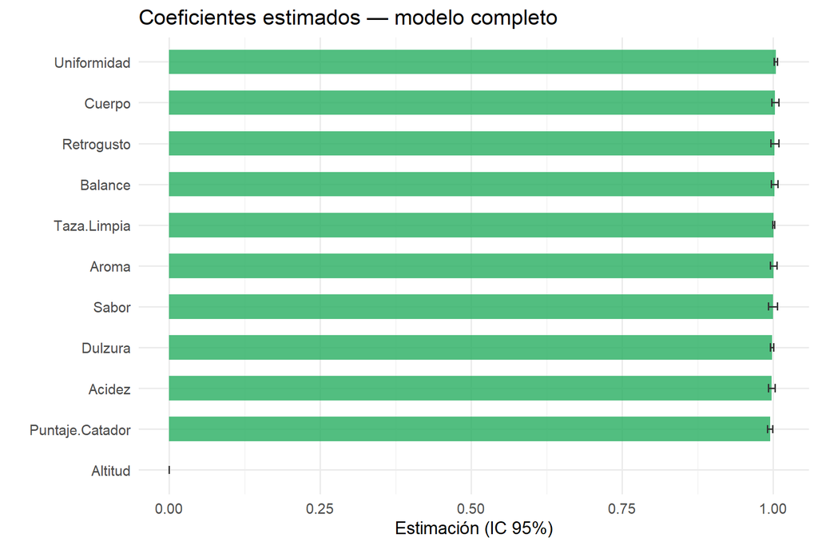

```r
tidy(modelo_completo, conf.int=TRUE) %>%
  filter(term != "(Intercept)") %>%
  ggplot(aes(x=reorder(term, estimate), y=estimate)) +
  geom_col(aes(fill=estimate > 0), alpha=0.8, width=0.6) +
  geom_errorbar(aes(ymin=conf.low, ymax=conf.high), width=0.2, color="#333333") +
  scale_fill_manual(values=c("TRUE"="#27ae60","FALSE"="#e74c3c"), guide="none") +
  coord_flip() +
  labs(title="Coeficientes estimados — modelo completo",
       x="", y="Estimación (IC 95%)") +
  theme_minimal(base_size = 14)
```

**Cómo se lee.** Cada barra es el coeficiente de una variable (cuánto cambia el puntaje total por una unidad más de esa variable, manteniendo las demás) y la línea negra su intervalo de confianza del 95 %. Los coeficientes de los atributos sensoriales son 0,995 a 1,005 (muy cerca de 1: la suma) y el de la altitud es -7,9e-07 (prácticamente 0).

# 4. Diagnósticos del modelo

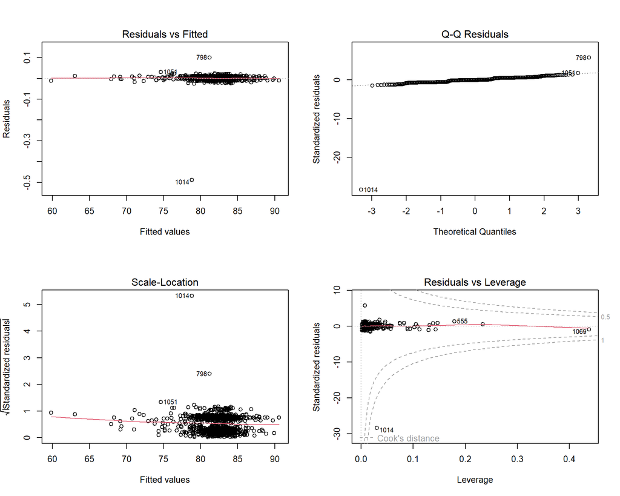

```r
par(mfrow=c(2,2))
plot(modelo_completo)
```

```r
par(mfrow=c(1,1))
```

```r
cat("Factor de inflación de varianza (VIF):\n")
```

```
## Factor de inflación de varianza (VIF):
```

```r
round(vif(modelo_completo), 2)
```

```
##           Aroma           Sabor      Retrogusto          Acidez          Cuerpo
##            2.38            5.61            4.58            2.64            2.47
##         Balance     Uniformidad     Taza.Limpia         Dulzura Puntaje.Catador
##            3.02            1.26            1.43            1.31            2.88
##         Altitud
##            1.08
```

**Cómo se lee.** Los gráficos de diagnóstico revisan los supuestos (residuos sin patrón, normalidad, varianza constante y puntos influyentes). Aquí **no tienen interpretación sustantiva**: los residuos son solo errores de redondeo del registro. El VIF mide cuánto se infla la varianza de un coeficiente por la correlación entre predictores; el máximo es 5,6 (variable Sabor): un VIF mayor de 10 indica colinealidad severa y entre 5 y 10, moderada: aquí la colinealidad es a lo sumo moderada.

# 5. Selección de variables

## 5.1. Stepwise AIC

```r
modelo_step <- stepAIC(modelo_completo, direction="both", trace=FALSE)
cat("Variables seleccionadas por AIC:\n")
```

```
## Variables seleccionadas por AIC:
```

```r
cat(names(coef(modelo_step))[-1], sep=", ")
```

```
## Aroma, Sabor, Retrogusto, Acidez, Cuerpo, Balance, Uniformidad, Taza.Limpia, Dulzura, Puntaje.Catador
```

```r
cat("\n\nComparación R² ajustado:\n")
```

```
##
##
## Comparación R² ajustado:
```

```r
cat("Modelo completo: ", round(summary(modelo_completo)$adj.r.squared, 4), "\n")
```

```
## Modelo completo:  1
```

```r
cat("Modelo stepwise:", round(summary(modelo_step)$adj.r.squared, 4), "\n")
```

```
## Modelo stepwise: 1
```

**Cómo se lee.** El procedimiento stepwise con criterio **AIC** agrega y quita variables para equilibrar ajuste y complejidad. Conserva 10 de las 11 variables y el R² ajustado casi no cambia (1,0000 frente a 1,0000): prescindir de variables cuesta poco.

## 5.2. Mejor subconjunto

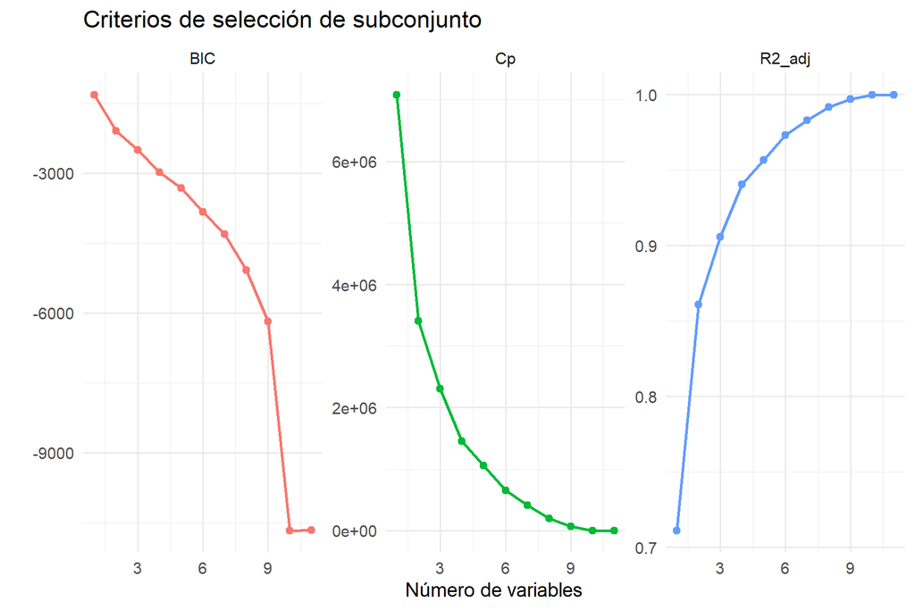

```r
reg_sub <- regsubsets(formula_completa, data=datos, nvmax=11)
reg_sum <- summary(reg_sub)

data.frame(
  k = 1:11,
  R2_adj = reg_sum$adjr2,
  Cp     = reg_sum$cp,
  BIC    = reg_sum$bic
) %>%
  tidyr::pivot_longer(-k, names_to="Métrica", values_to="Valor") %>%
  ggplot(aes(k, Valor, color=Métrica)) +
  geom_line(linewidth=1) + geom_point(size=2) +
  facet_wrap(~Métrica, scales="free_y") +
  labs(title="Criterios de selección de subconjunto",
       x="Número de variables", y="") +
  theme_minimal(base_size = 14) + theme(legend.position="none")
```

**Cómo se lee.** Para cada número de variables se muestra el mejor subconjunto según tres criterios: R² ajustado (más alto es mejor), Cp de Mallows y BIC (más bajos son mejores). El R² ajustado se maximiza con 10 variables y el BIC se minimiza con 10: a partir de ahí agregar variables mejora poco.

# 6. Predicción y evaluación

```r
set.seed(42)
idx_test   <- sample(seq_len(nrow(datos)), size = floor(0.25 * nrow(datos)))
datos_test <- datos[ idx_test, ]
datos_tr   <- datos[-idx_test, ]

modelo_final <- lm(formula_completa, data=datos_tr)
pred_vals    <- predict(modelo_final, datos_test)

rmse <- sqrt(mean((datos_test$Puntaje.Total - pred_vals)^2))
mae  <- mean(abs(datos_test$Puntaje.Total - pred_vals))
# R² predictivo en test: 1 - SSE/SST. Puede ser negativo si el modelo
# predice peor que usar la media observada del conjunto de entrenamiento.
r2_test <- 1 - sum((datos_test$Puntaje.Total - pred_vals)^2) /
  sum((datos_test$Puntaje.Total - mean(datos_tr$Puntaje.Total))^2)

# Se reporta aparte la correlación al cuadrado; no sustituye al R² predictivo.
r2_correlacion <- cor(datos_test$Puntaje.Total, pred_vals)^2

cat("RMSE:", round(rmse, 4), "\n")
```

```
## RMSE: 0.0319
```

```r
cat("MAE: ", round(mae, 4), "\n")
```

```
## MAE:  0.0078
```

```r
cat("R² predictivo en test:", round(r2_test, 4), "\n")
```

```
## R² predictivo en test: 0.9999
```

```r
cat("Correlación(real, predicho)^2:", round(r2_correlacion, 4), "\n")
```

```
## Correlación(real, predicho)^2: 0.9999
```

**Qué hacemos y por qué.** Para saber si el modelo generaliza, se separa un 25 % de los lotes como **prueba** (el modelo no los ve al ajustarse) y se mide el error ahí.

**Cómo se lee.** En los 267 lotes de prueba, el RMSE es 0,032 puntos, el MAE 0,008 y el R² predictivo 0,9999. Un R² predictivo cercano a 1 aquí **no demuestra** capacidad predictiva real: se debe a que el puntaje total es la suma de los atributos que el modelo recibe como entrada.

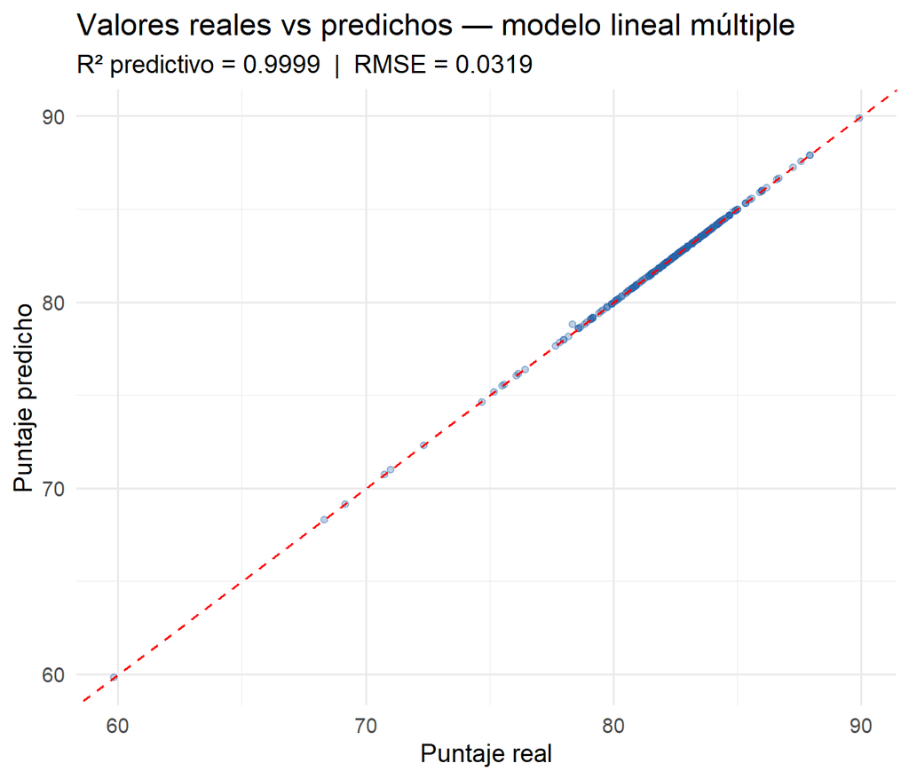

```r
data.frame(real=datos_test$Puntaje.Total, pred=pred_vals) %>%
  ggplot(aes(real, pred)) +
  geom_point(alpha=0.3, color="#2563a8", size=1.5) +
  geom_abline(slope=1, intercept=0, color="red", linetype="dashed") +
  labs(title="Valores reales vs predichos — modelo lineal múltiple",
       subtitle=paste0("R² predictivo = ", round(r2_test,4), "  |  RMSE = ", round(rmse,4)),
       x="Puntaje real", y="Puntaje predicho") +
  theme_minimal(base_size = 14)
```

**Cómo se lee.** Cada punto es un lote de prueba; todos caen sobre la diagonal (predicho = real). Es el reflejo gráfico de la identidad contable.

# 7. Modelo sin circularidad: puntaje total a partir del origen y del grano verde

Se predice el puntaje total solo con variables que **no** forman parte de la suma: altitud, humedad, defectos de categoría 1 y 2, método de procesamiento y país de origen (los cinco con más lotes y “Otro”). Se usa la misma partición train/test de la sección 6.

```r
top5 <- names(sort(table(datos_tr$Country.of.Origin), decreasing = TRUE))[1:5]
prep_ext <- function(d) {
  d %>% mutate(
    Proceso = factor(ifelse(is.na(Processing.Method) | trimws(Processing.Method) == "",
                            "Desconocido", Processing.Method)),
    Pais    = factor(ifelse(Country.of.Origin %in% top5, Country.of.Origin, "Otro"),
                     levels = c(top5, "Otro"))
  )
}
tr_ext <- prep_ext(datos_tr); te_ext <- prep_ext(datos_test)
te_ext$Proceso <- factor(te_ext$Proceso, levels = levels(tr_ext$Proceso))

modelo_ext <- lm(Puntaje.Total ~ Altitud + Humedad + Defectos.Cat1 + Defectos.Cat2 + Proceso + Pais,
                 data = tr_ext)
summary(modelo_ext)
```

```
##
## Call:
## lm(formula = Puntaje.Total ~ Altitud + Humedad + Defectos.Cat1 +
##     Defectos.Cat2 + Proceso + Pais, data = tr_ext)
##
## Residuals:
##      Min       1Q   Median       3Q      Max
## -17.2740  -1.0347   0.1836   1.2844   6.9050
##
## Coefficients:
##                                    Estimate Std. Error t value Pr(>|t|)
## (Intercept)                      80.7078621  0.4899267 164.735  < 2e-16 ***
## Altitud                           0.0015524  0.0002248   6.907 1.02e-11 ***
## Humedad                          -3.7830667  1.8738736  -2.019  0.04384 *
## Defectos.Cat1                    -0.0447082  0.0505640  -0.884  0.37686
## Defectos.Cat2                    -0.0916666  0.0172102  -5.326 1.31e-07 ***
## ProcesoNatural / Dry              0.1060121  0.3716089   0.285  0.77551
## ProcesoOther                     -1.9154629  0.6425029  -2.981  0.00296 **
## ProcesoPulped natural / honey    -0.8200763  0.9869916  -0.831  0.40629
## ProcesoSemi-washed / Semi-pulped  0.0344786  0.4898670   0.070  0.94391
## ProcesoWashed / Wet              -0.6488982  0.3275366  -1.981  0.04792 *
## PaisColombia                      0.9513453  0.3071830   3.097  0.00202 **
## PaisGuatemala                     0.6184102  0.2912049   2.124  0.03401 *
## PaisBrazil                        1.0451632  0.3618527   2.888  0.00398 **
## PaisTaiwan                        1.2229040  0.4097158   2.985  0.00293 **
## PaisOtro                          0.8487238  0.2373146   3.576  0.00037 ***
## ---
## Signif. codes:  0 '***' 0.001 '**' 0.01 '*' 0.05 '.' 0.1 ' ' 1
##
## Residual standard error: 2.251 on 787 degrees of freedom
## Multiple R-squared:  0.1953, Adjusted R-squared:  0.1809
## F-statistic: 13.64 on 14 and 787 DF,  p-value: < 2.2e-16
```

```r
pred_ext <- predict(modelo_ext, te_ext)
r2_ext <- 1 - sum((te_ext$Puntaje.Total - pred_ext)^2) /
  sum((te_ext$Puntaje.Total - mean(tr_ext$Puntaje.Total))^2)
cat("RMSE en test:", round(sqrt(mean((te_ext$Puntaje.Total - pred_ext)^2)), 3),
    " | R² predictivo en test:", round(r2_ext, 3), "\n")
```

```
## RMSE en test: 2.876  | R² predictivo en test: 0.131
```

```r
cat("Referencia: desviación estándar del puntaje en test:", round(sd(te_ext$Puntaje.Total), 3), "\n")
```

```
## Referencia: desviación estándar del puntaje en test: 3.077
```

**Cómo se lee.** Con este modelo el R² predictivo en prueba es 0,131 y el RMSE 2,88 puntos, frente a una desviación estándar de 3,08: el origen y el estado del grano verde explican muy poco del puntaje total. Para la altitud, el coeficiente es de 0,16 puntos por cada 100 m más. Es la cifra honesta para presentar: contrasta con el R² ≈ 1 del modelo con los atributos sensoriales, que solo refleja cómo se calcula el puntaje.

Este modelo responde una pregunta real (¿cuánto del puntaje se explica por el origen y el estado del grano verde?) y su R² predictivo es la cifra que conviene presentar; el R² ≈ 1 del modelo con los atributos sensoriales solo confirma cómo se calcula el puntaje.

# Conclusiones

1. **El puntaje total es la suma de los diez atributos** (diferencia cero en 521 de 1.069 lotes y de redondeo en el resto): cualquier modelo con esos atributos tiene R² ≈ 1.
2. La regresión múltiple, el stepwise y la selección de subconjunto **reconstruyen** esa suma; los diagnósticos y los valores p no tienen interpretación sustantiva.
3. El modelo sin circularidad (origen, altitud, humedad, defectos y proceso) alcanza un R² predictivo de 0,131: es la medida de capacidad predictiva real.
4. Estos modelos son **descriptivos**; no permiten predecir la calidad antes de la catación ni sustituyen la evaluación del CQI.